# Notebook

## Problem Statement

### Context

AllLife Bank is a US bank that has a growing customer base. The majority of these customers are liability customers (depositors) with varying sizes of deposits. The number of customers who are also borrowers (asset customers) is quite small, and the bank is interested in expanding this base rapidly to bring in more loan business and in the process, earn more through the interest on loans. In particular, the management wants to explore ways of converting its liability customers to personal loan customers (while retaining them as depositors).

A campaign that the bank ran last year for liability customers showed a healthy conversion rate of over 9% success. This has encouraged the retail marketing department to devise campaigns with better target marketing to increase the success ratio.

You as a Data scientist at AllLife bank have to build a model that will help the marketing department to identify the potential customers who have a higher probability of purchasing the loan.

### Objective

To predict whether a liability customer will buy personal loans, to understand which customer attributes are most significant in driving purchases, and identify which segment of customers to target more.

### Data Dictionary

- `ID`: Customer ID
- `Age`: Customer’s age in completed years
- `Experience`: #years of professional experience
- `Income`: Annual income of the customer (in thousand dollars)
- `ZIP Code`: Home Address ZIP code.
- `Family`: the Family size of the customer
- `CCAvg`: Average spending on credit cards per month (in thousand dollars)
- `Education`: Education Level. 1: Undergrad; 2: Graduate;3: Advanced/Professional
- `Mortgage`: Value of house mortgage if any. (in thousand dollars)
- `Personal_Loan`: Did this customer accept the personal loan offered in the last campaign? (0: No, 1: Yes)
- `Securities_Account`: Does the customer have securities account with the bank? (0: No, 1: Yes)
- `CD_Account`: Does the customer have a certificate of deposit (CD) account with the bank? (0: No, 1: Yes)
- `Online`: Do customers use internet banking facilities? (0: No, 1: Yes)
- `CreditCard`: Does the customer use a credit card issued by any other Bank (excluding All life Bank)? (0: No, 1: Yes)

## Importing necessary libraries

```python
# Installing the libraries with the specified version.
# pip install numpy==1.25.2 pandas==1.5.3 matplotlib==3.7.1 seaborn==0.13.1 scikit-learn==1.2.2 sklearn-pandas==2.2.0 -q --user
```

**Note**:

1. After running the above cell, kindly restart the notebook kernel (for Jupyter Notebook) or runtime (for Google Colab), write the relevant code for the project from the next cell, and run all cells sequentially from the next cell.
2. On executing the above line of code, you might see a warning regarding package dependencies. This error message can be ignored as the above code ensures that all necessary libraries and their dependencies are maintained to successfully execute the code in this notebook.

```python
import numpy as np
import pandas as pd
import matplotlib.pyplot as plt
import seaborn as sns
from sklearn.model_selection import train_test_split, cross_val_score, GridSearchCV
from sklearn.preprocessing import StandardScaler
from sklearn.linear_model import LogisticRegression
from sklearn.tree import DecisionTreeClassifier
from sklearn.ensemble import RandomForestClassifier
from sklearn.metrics import accuracy_score, precision_score, recall_score, f1_score, roc_auc_score, confusion_matrix, classification_report, roc_curve
from sklearn_pandas import DataFrameMapper
import warnings
```

## Loading the dataset

```python
data = pd.read_csv('./Loan_Modelling.csv')
plt.style.use('seaborn-whitegrid')
sns.set_palette('Set2')
plt.rcParams['figure.figsize'] = (12, 8)
plt.rcParams['font.size'] = 12
```

[output not shown]

## Data Overview

- Observations
- Sanity checks

```python
print('data shape:', data.shape)
print("First 5 rows of the dataset:")
display(data.head())
print("\nData Types:")
print(data.dtypes)

# Check for missing values
print("\nMissing Values:")
print(data.isnull().sum())

# Summary statistics
print("\nSummary Statistics:")
display(data.describe())

# Check the distribution of the target variable
print("\nDistribution of Personal Loan:")
print(data['Personal_Loan'].value_counts())
print(f"Percentage of customers who took a personal loan: {data['Personal_Loan'].mean() * 100:.2f}%")
```

```
data shape: (5000, 14)
First 5 rows of the dataset:
```

|  | ID | Age | Experience | Income | ZIPCode | Family | CCAvg | Education | Mortgage | Personal_Loan | Securities_Account | CD_Account | Online | CreditCard |
| --- | --- | --- | --- | --- | --- | --- | --- | --- | --- | --- | --- | --- | --- | --- |
| 0 | 1 | 25 | 1 | 49 | 91107 | 4 | 1.6 | 1 | 0 | 0 | 1 | 0 | 0 | 0 |
| 1 | 2 | 45 | 19 | 34 | 90089 | 3 | 1.5 | 1 | 0 | 0 | 1 | 0 | 0 | 0 |
| 2 | 3 | 39 | 15 | 11 | 94720 | 1 | 1.0 | 1 | 0 | 0 | 0 | 0 | 0 | 0 |
| 3 | 4 | 35 | 9 | 100 | 94112 | 1 | 2.7 | 2 | 0 | 0 | 0 | 0 | 0 | 0 |
| 4 | 5 | 35 | 8 | 45 | 91330 | 4 | 1.0 | 2 | 0 | 0 | 0 | 0 | 0 | 1 |

```
Data Types:
ID                      int64
Age                     int64
Experience              int64
Income                  int64
ZIPCode                 int64
Family                  int64
CCAvg                 float64
Education               int64
Mortgage                int64
Personal_Loan           int64
Securities_Account      int64
CD_Account              int64
Online                  int64
CreditCard              int64
dtype: object

Missing Values:
ID                    0
Age                   0
Experience            0
Income                0
ZIPCode               0
Family                0
CCAvg                 0
Education             0
Mortgage              0
Personal_Loan         0
Securities_Account    0
CD_Account            0
Online                0
CreditCard            0
dtype: int64

Summary Statistics:
```

|  | ID | Age | Experience | Income | ZIPCode | Family | CCAvg | Education | Mortgage | Personal_Loan | Securities_Account | CD_Account | Online | CreditCard |
| --- | --- | --- | --- | --- | --- | --- | --- | --- | --- | --- | --- | --- | --- | --- |
| count | 5000.000000 | 5000.000000 | 5000.000000 | 5000.000000 | 5000.000000 | 5000.000000 | 5000.000000 | 5000.000000 | 5000.000000 | 5000.000000 | 5000.000000 | 5000.00000 | 5000.000000 | 5000.000000 |
| mean | 2500.500000 | 45.338400 | 20.104600 | 73.774200 | 93169.257000 | 2.396400 | 1.937938 | 1.881000 | 56.498800 | 0.096000 | 0.104400 | 0.06040 | 0.596800 | 0.294000 |
| std | 1443.520003 | 11.463166 | 11.467954 | 46.033729 | 1759.455086 | 1.147663 | 1.747659 | 0.839869 | 101.713802 | 0.294621 | 0.305809 | 0.23825 | 0.490589 | 0.455637 |
| min | 1.000000 | 23.000000 | -3.000000 | 8.000000 | 90005.000000 | 1.000000 | 0.000000 | 1.000000 | 0.000000 | 0.000000 | 0.000000 | 0.00000 | 0.000000 | 0.000000 |
| 25% | 1250.750000 | 35.000000 | 10.000000 | 39.000000 | 91911.000000 | 1.000000 | 0.700000 | 1.000000 | 0.000000 | 0.000000 | 0.000000 | 0.00000 | 0.000000 | 0.000000 |
| 50% | 2500.500000 | 45.000000 | 20.000000 | 64.000000 | 93437.000000 | 2.000000 | 1.500000 | 2.000000 | 0.000000 | 0.000000 | 0.000000 | 0.00000 | 1.000000 | 0.000000 |
| 75% | 3750.250000 | 55.000000 | 30.000000 | 98.000000 | 94608.000000 | 3.000000 | 2.500000 | 3.000000 | 101.000000 | 0.000000 | 0.000000 | 0.00000 | 1.000000 | 1.000000 |
| max | 5000.000000 | 67.000000 | 43.000000 | 224.000000 | 96651.000000 | 4.000000 | 10.000000 | 3.000000 | 635.000000 | 1.000000 | 1.000000 | 1.00000 | 1.000000 | 1.000000 |

```
Distribution of Personal Loan:
0    4520
1     480
Name: Personal_Loan, dtype: int64
Percentage of customers who took a personal loan: 9.60%
```

## Exploratory Data Analysis.

- EDA is an important part of any project involving data.
- It is important to investigate and understand the data better before building a model with it.
- A few questions have been mentioned below which will help you approach the analysis in the right manner and generate insights from the data.
- A thorough analysis of the data, in addition to the questions mentioned below, should be done.

**Questions**:

1. What is the distribution of mortgage attribute? Are there any noticeable patterns or outliers in the distribution?
2. How many customers have credit cards?
3. What are the attributes that have a strong correlation with the target attribute (personal loan)?
4. How does a customer's interest in purchasing a loan vary with their age?
5. How does a customer's interest in purchasing a loan vary with their education?

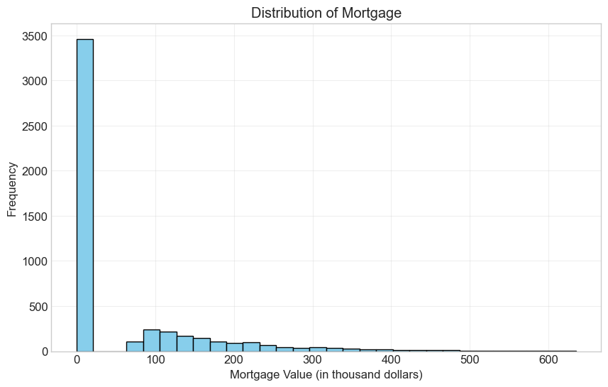

```
Descriptive Statistics for Mortgage:
count    5000.000000
mean       56.498800
std       101.713802
min         0.000000
25%         0.000000
50%         0.000000
75%       101.000000
max       635.000000
Name: Mortgage, dtype: float64
```

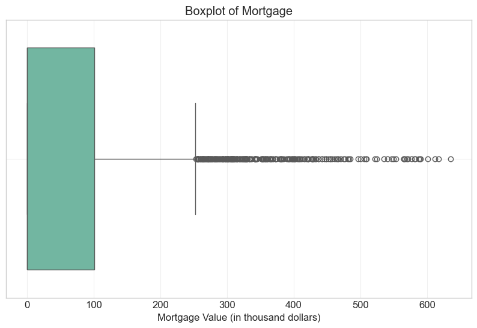

```
Number of customers with credit cards:
0    3530
1    1470
Name: CreditCard, dtype: int64
Percentage of customers with credit cards: 29.40%
```

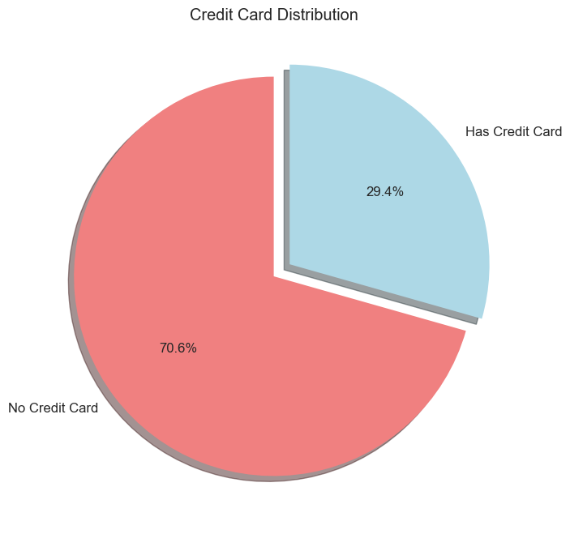

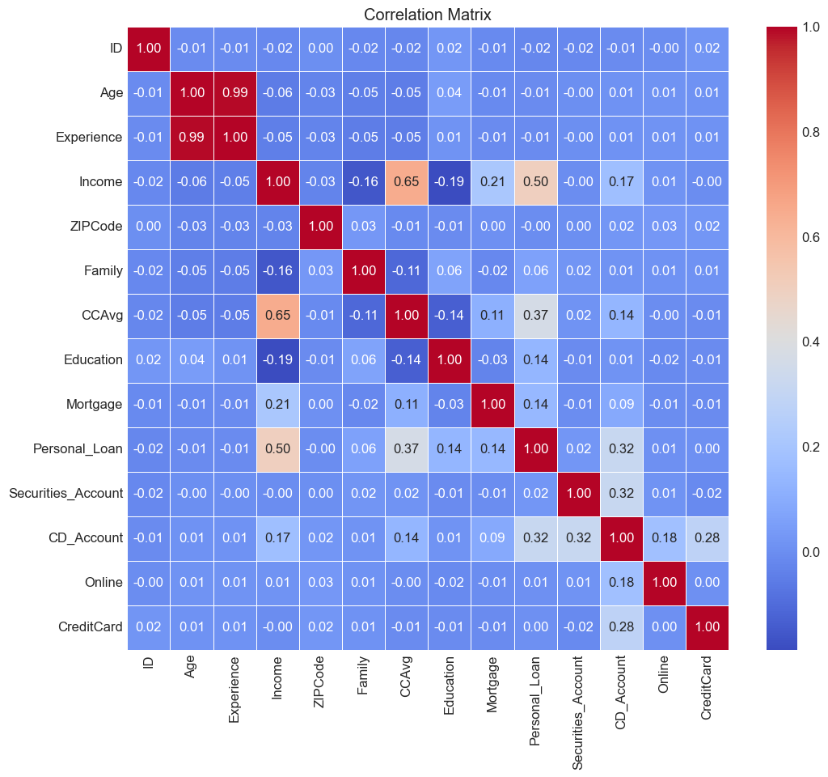

```
Correlation with Personal Loan:
Personal_Loan         1.000000
Income                0.502462
CCAvg                 0.366889
CD_Account            0.316355
Mortgage              0.142095
Education             0.136722
Family                0.061367
Securities_Account    0.021954
Online                0.006278
CreditCard            0.002802
ZIPCode              -0.002974
Experience           -0.007413
Age                  -0.007726
ID                   -0.024801
Name: Personal_Loan, dtype: float64
```

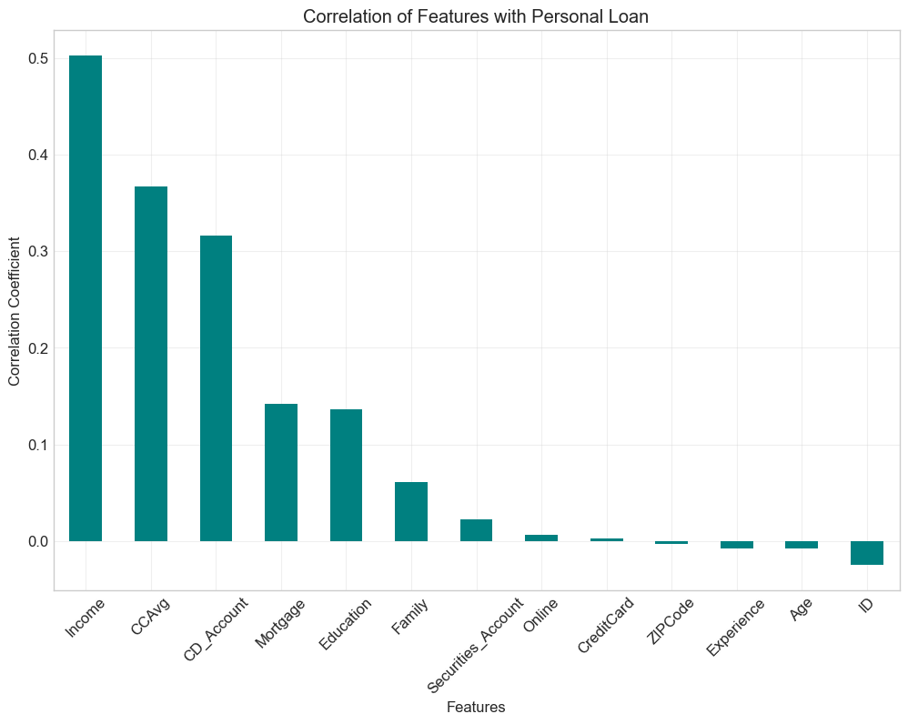

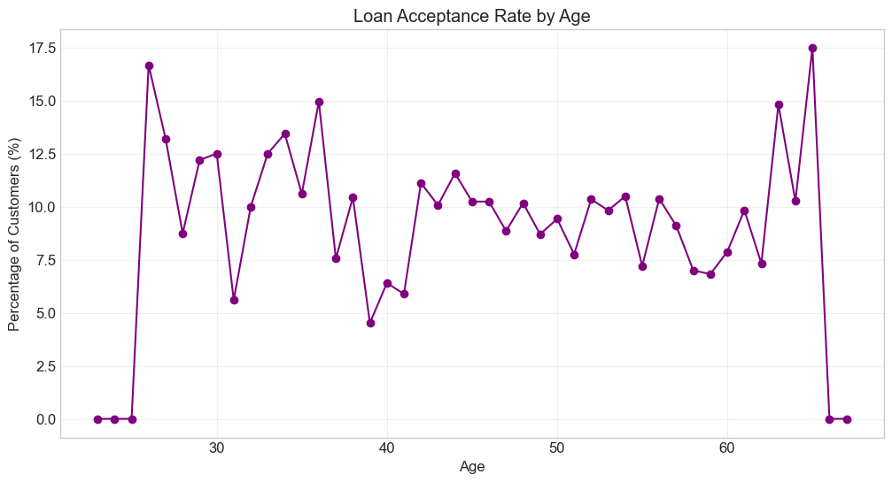

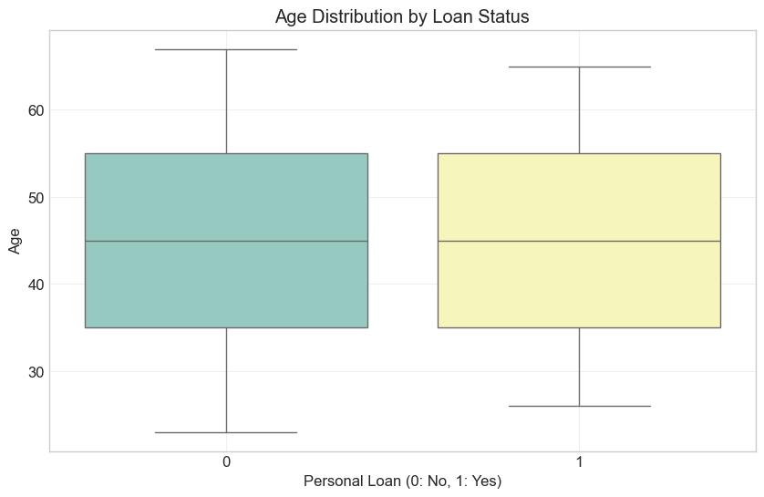

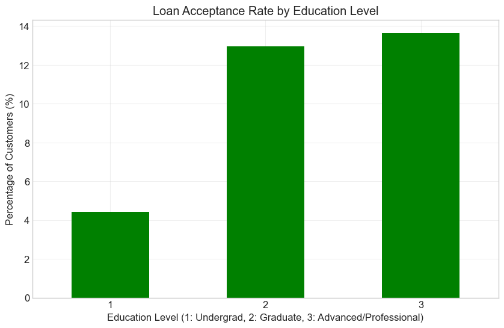

```
Loan Acceptance Rate by Education Level:
Personal_Loan          0          1
Education
1              95.562977   4.437023
2              87.027798  12.972202
3              86.342438  13.657562
```

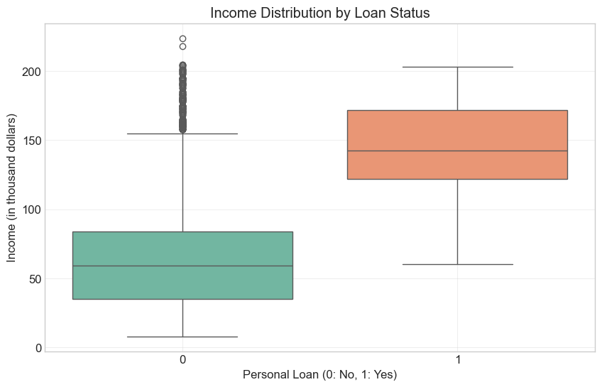

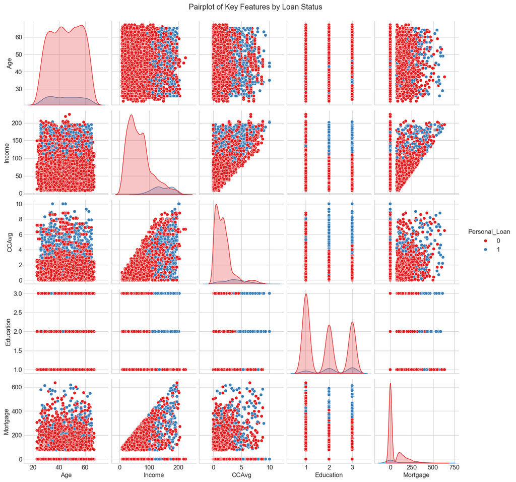

```python
# 1. What is the distribution of mortgage attribute? Are there any noticeable patterns or outliers in the distribution?
plt.figure(figsize=(10, 6))
plt.hist(data['Mortgage'], bins=30, color='skyblue', edgecolor='black')
plt.title('Distribution of Mortgage')
plt.xlabel('Mortgage Value (in thousand dollars)')
plt.ylabel('Frequency')
plt.grid(True, alpha=0.3)
plt.show()

# Descriptive statistics for Mortgage
print("Descriptive Statistics for Mortgage:")
print(data['Mortgage'].describe())

# Outliers check using a boxplot
plt.figure(figsize=(10, 6))
sns.boxplot(x=data['Mortgage'])
plt.title('Boxplot of Mortgage')
plt.xlabel('Mortgage Value (in thousand dollars)')
plt.grid(True, alpha=0.3)
plt.show()

# ---------------------------

# 2. How many customers have credit cards?
credit_card_counts = data['CreditCard'].value_counts()
print("\nNumber of customers with credit cards:")
print(credit_card_counts)
print(f"Percentage of customers with credit cards: {credit_card_counts[1] / len(data) * 100:.2f}%")

plt.figure(figsize=(8, 8))
plt.pie(credit_card_counts, labels=['No Credit Card', 'Has Credit Card'],
        autopct='%1.1f%%', startangle=90, colors=['lightcoral', 'lightblue'],
        shadow=True, explode=(0, 0.1))
plt.title('Credit Card Distribution')
plt.show()

# ---------------------------
# 3. What are the attributes that have a strong correlation with the target attribute (personal loan)?

# correlation matrix
correlation_matrix = data.corr()
plt.figure(figsize=(12, 10))
sns.heatmap(correlation_matrix, annot=True, cmap='coolwarm', fmt='.2f', linewidths=0.5)
plt.title('Correlation Matrix')
plt.show()

# Display correlations with Personal_Loan in descending order
personal_loan_corr = correlation_matrix['Personal_Loan'].sort_values(ascending=False)
print("\nCorrelation with Personal Loan:")
print(personal_loan_corr)

# Bar plot for visualization
plt.figure(figsize=(12, 8))
personal_loan_corr = personal_loan_corr.drop('Personal_Loan')  # Drop self-correlation
personal_loan_corr.plot(kind='bar', color='teal')
plt.title('Correlation of Features with Personal Loan')
plt.xlabel('Features')
plt.ylabel('Correlation Coefficient')
plt.grid(True, alpha=0.3)
plt.xticks(rotation=45)
plt.show()


# ---------------------------
# 4. How does a customer's interest in purchasing a loan vary with their age?
plt.figure(figsize=(12, 6))
age_loan_data = data.groupby('Age')['Personal_Loan'].mean() * 100
age_loan_data.plot(kind='line', marker='o', color='purple')
plt.title('Loan Acceptance Rate by Age')
plt.xlabel('Age')
plt.ylabel('Percentage of Customers (%)')
plt.grid(True, alpha=0.3)
plt.show()

# Boxplot to compare age distributions
plt.figure(figsize=(10, 6))
sns.boxplot(x='Personal_Loan', y='Age', data=data, palette='Set3')
plt.title('Age Distribution by Loan Status')
plt.xlabel('Personal Loan (0: No, 1: Yes)')
plt.ylabel('Age')
plt.grid(True, alpha=0.3)
plt.show()


# ---------------------------
# 5. How does a customer's interest in purchasing a loan vary with their education?
plt.figure(figsize=(10, 6))
education_loan_data = data.groupby('Education')['Personal_Loan'].mean() * 100
education_loan_data.plot(kind='bar', color='green')
plt.title('Loan Acceptance Rate by Education Level')
plt.xlabel('Education Level (1: Undergrad, 2: Graduate, 3: Advanced/Professional)')
plt.ylabel('Percentage of Customers (%)')
plt.grid(True, alpha=0.3)
plt.xticks(rotation=0)
plt.show()

# contingency table
education_loan_table = pd.crosstab(data['Education'], data['Personal_Loan'], normalize='index') * 100
print("\nLoan Acceptance Rate by Education Level:")
print(education_loan_table)


# Additional EDA: Income vs Loan
plt.figure(figsize=(10, 6))
sns.boxplot(x='Personal_Loan', y='Income', data=data, palette='Set2')
plt.title('Income Distribution by Loan Status')
plt.xlabel('Personal Loan (0: No, 1: Yes)')
plt.ylabel('Income (in thousand dollars)')
plt.grid(True, alpha=0.3)
plt.show()

# Create a pairplot for selected features
sns.pairplot(data[['Age', 'Income', 'CCAvg', 'Education', 'Mortgage', 'Personal_Loan']],
             hue='Personal_Loan', palette='Set1')
plt.suptitle('Pairplot of Key Features by Loan Status', y=1.02)
plt.show()
```

## Data Preprocessing

- Missing value treatment
- Feature engineering (if needed)
- Outlier detection and treatment (if needed)
- Preparing data for modeling
- Any other preprocessing steps (if needed)

```
Missing Values:
ID                    0
Age                   0
Experience            0
Income                0
ZIPCode               0
Family                0
CCAvg                 0
Education             0
Mortgage              0
Personal_Loan         0
Securities_Account    0
CD_Account            0
Online                0
CreditCard            0
dtype: int64

Unique values in categorical variables:
Education: [1 2 3]
Securities_Account: [1 0]
CD_Account: [0 1]
Online: [0 1]
CreditCard: [0 1]
Personal_Loan: [0 1]
```

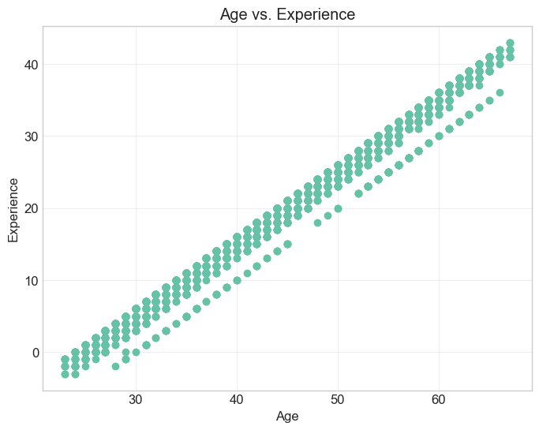

```
Correlation between Age and Experience: 0.9942148569683315

Negative Experience values:
      Age  Experience  Income  Family  CCAvg  Education  Mortgage  \
89     25          -1     113       4   2.30          3         0
226    24          -1      39       2   1.70          2         0
315    24          -2      51       3   0.30          3         0
451    28          -2      48       2   1.75          3        89
524    24          -1      75       4   0.20          1         0
536    25          -1      43       3   2.40          2       176
540    25          -1     109       4   2.30          3       314
576    25          -1      48       3   0.30          3         0
583    24          -1      38       2   1.70          2         0
597    24          -2     125       2   7.20          1         0
649    25          -1      82       4   2.10          3         0
```

[output cut: 95 more lines]

```python
print("Missing Values:")
print(data.isnull().sum())

# Check for inconsistencies in categorical variables
print("\nUnique values in categorical variables:")
for col in ['Education', 'Securities_Account', 'CD_Account', 'Online', 'CreditCard', 'Personal_Loan']:
    print(f"{col}: {data[col].unique()}")


data_processed = data.drop(['ID', 'ZIPCode'], axis=1)

plt.figure(figsize=(8, 6))
plt.scatter(data_processed['Age'], data_processed['Experience'])
plt.title('Age vs. Experience')
plt.xlabel('Age')
plt.ylabel('Experience')
plt.grid(True, alpha=0.3)
plt.show()

print("\nCorrelation between Age and Experience:", data_processed['Age'].corr(data_processed['Experience']))


print("\nNegative Experience values:")
print(data_processed[data_processed['Experience'] < 0])


# Replace negative experience values with a calculated value based on age
data_processed.loc[data_processed['Experience'] < 0, 'Experience'] = data_processed.loc[data_processed['Experience'] < 0, 'Age'] - 21
```

## Model Building

### Model Evaluation Criterion

# Metrics used for model evaluation:

# 1. Accuracy - Overall correctness of the model

# 2. Precision - Measures the accuracy of positive predictions

# 3. Recall - Measures the ability to find all positive instances

# 4. F1-score - Harmonic mean of precision and recall

# 5. ROC-AUC - Area under the ROC curve, measures the ability to distinguish between classes

# Since we're dealing with an imbalanced dataset (low percentage of loan takers),

# we will prioritize precision, recall, F1-score, and ROC-AUC over simple accuracy.

### Model Building

```
Training set shape: (3500, 11)
Testing set shape: (1500, 11)
Model 1: Logistic Regression
Accuracy: 0.9500
Precision: 0.8108
Recall: 0.6250
F1-score: 0.7059
ROC-AUC: 0.9643
```

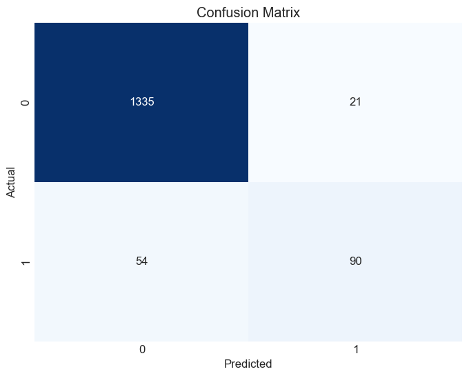

```
Classification Report:
              precision    recall  f1-score   support

           0       0.96      0.98      0.97      1356
           1       0.81      0.62      0.71       144

    accuracy                           0.95      1500
   macro avg       0.89      0.80      0.84      1500
weighted avg       0.95      0.95      0.95      1500
```

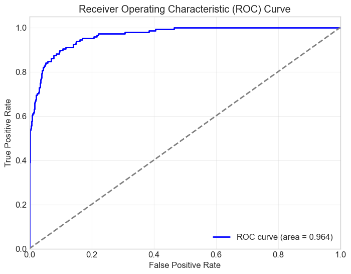

```
Model 2: Decision Tree
Accuracy: 0.9807
Precision: 0.8912
Recall: 0.9097
F1-score: 0.9003
ROC-AUC: 0.9490
```

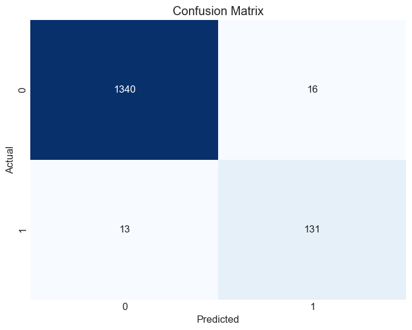

```
Classification Report:
              precision    recall  f1-score   support

           0       0.99      0.99      0.99      1356
           1       0.89      0.91      0.90       144

    accuracy                           0.98      1500
   macro avg       0.94      0.95      0.94      1500
weighted avg       0.98      0.98      0.98      1500
```

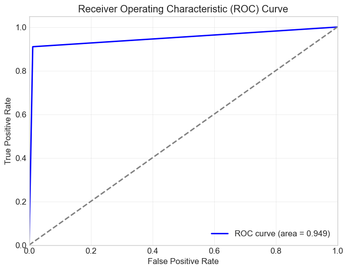

```
Model 3: Random Forest
Accuracy: 0.9893
Precision: 0.9706
Recall: 0.9167
F1-score: 0.9429
ROC-AUC: 0.9984
```

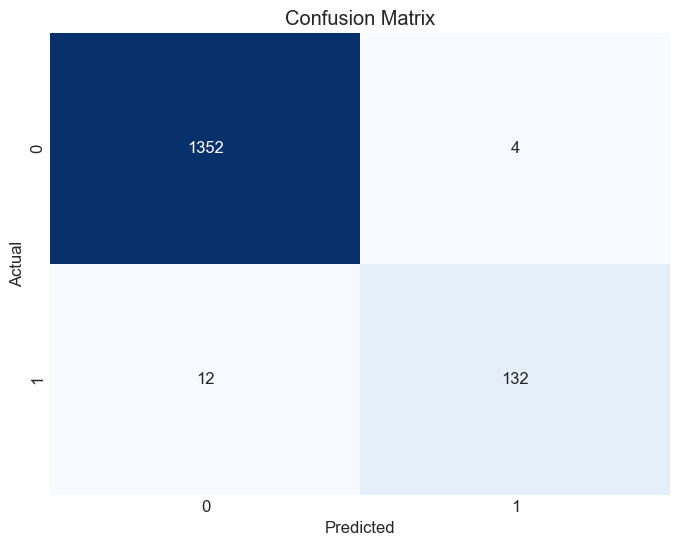

```
Classification Report:
              precision    recall  f1-score   support

           0       0.99      1.00      0.99      1356
           1       0.97      0.92      0.94       144

    accuracy                           0.99      1500
   macro avg       0.98      0.96      0.97      1500
weighted avg       0.99      0.99      0.99      1500
```

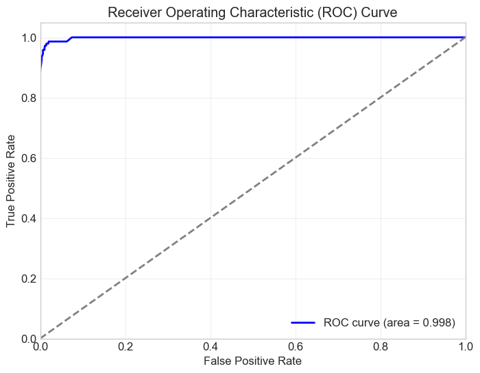

```python
# Prep data for model building

X = data_processed.drop('Personal_Loan', axis=1)
y = data_processed['Personal_Loan']

# Split the data into training and testing sets
X_train, X_test, y_train, y_test = train_test_split(X, y, test_size=0.3, random_state=42, stratify=y)
print(f"Training set shape: {X_train.shape}")
print(f"Testing set shape: {X_test.shape}")


# Standardize numerical features
scaler = StandardScaler()
numerical_features = ['Age', 'Experience', 'Income', 'Family', 'CCAvg', 'Mortgage']
X_train[numerical_features] = scaler.fit_transform(X_train[numerical_features])
X_test[numerical_features] = scaler.transform(X_test[numerical_features])

# Function to evaluate models
def evaluate_model(model, X_train, X_test, y_train, y_test):
    # Train the model
    model.fit(X_train, y_train)

    # Make predictions
    y_pred = model.predict(X_test)
    y_pred_proba = model.predict_proba(X_test)[:, 1]

    # Calculate metrics
    acc = accuracy_score(y_test, y_pred)
    prec = precision_score(y_test, y_pred)
    rec = recall_score(y_test, y_pred)
    f1 = f1_score(y_test, y_pred)
    roc_auc = roc_auc_score(y_test, y_pred_proba)

    # Print metrics
    print(f"Accuracy: {acc:.4f}")
    print(f"Precision: {prec:.4f}")
    print(f"Recall: {rec:.4f}")
    print(f"F1-score: {f1:.4f}")
    print(f"ROC-AUC: {roc_auc:.4f}")

    # Display confusion matrix
    cm = confusion_matrix(y_test, y_pred)
    plt.figure(figsize=(8, 6))
    sns.heatmap(cm, annot=True, fmt='d', cmap='Blues', cbar=False)
    plt.title('Confusion Matrix')
    plt.xlabel('Predicted')
    plt.ylabel('Actual')
    plt.show()

    # Display classification report
    print("\nClassification Report:")
    print(classification_report(y_test, y_pred))

    # Plot ROC curve
    fpr, tpr, _ = roc_curve(y_test, y_pred_proba)
    plt.figure(figsize=(8, 6))
    plt.plot(fpr, tpr, color='blue', lw=2, label=f'ROC curve (area = {roc_auc:.3f})')
    plt.plot([0, 1], [0, 1], color='gray', lw=2, linestyle='--')
    plt.xlim([0.0, 1.0])
    plt.ylim([0.0, 1.05])
    plt.xlabel('False Positive Rate')
    plt.ylabel('True Positive Rate')
    plt.title('Receiver Operating Characteristic (ROC) Curve')
    plt.legend(loc="lower right")
    plt.grid(True, alpha=0.3)
    plt.show()

    return {
        'accuracy': acc,
        'precision': prec,
        'recall': rec,
        'f1_score': f1,
        'roc_auc': roc_auc,
        'model': model
    }


# 1. Logistic Regression
# Why logistic regression:
# Quantifies marginal effect of each attribute


print("\nModel 1: Logistic Regression")
lr_model = LogisticRegression(random_state=42, max_iter=1000)
lr_results = evaluate_model(lr_model, X_train, X_test, y_train, y_test)

# 2. Decision Tree
# Why decision tree:
# Useful for direct rule‑based targeting.
print("\nModel 2: Decision Tree")
dt_model = DecisionTreeClassifier(random_state=42)
dt_results = evaluate_model(dt_model, X_train, X_test, y_train, y_test)

# 3. Random Forest
# Why random forest:
# Handles non‑linear feature interactions
print("\nModel 3: Random Forest")
rf_model = RandomForestClassifier(random_state=42)
rf_results = evaluate_model(rf_model, X_train, X_test, y_train, y_test)
```

## Model Performance Improvement

```
Improving Logistic Regression...
Best parameters: {'C': 10, 'penalty': 'l1', 'solver': 'liblinear'}
Accuracy: 0.9520
Precision: 0.8158
Recall: 0.6458
F1-score: 0.7209
ROC-AUC: 0.9640
```

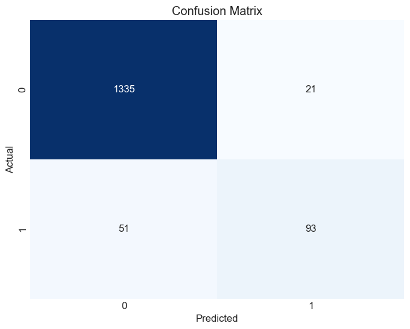

```
Classification Report:
              precision    recall  f1-score   support

           0       0.96      0.98      0.97      1356
           1       0.82      0.65      0.72       144

    accuracy                           0.95      1500
   macro avg       0.89      0.82      0.85      1500
weighted avg       0.95      0.95      0.95      1500
```

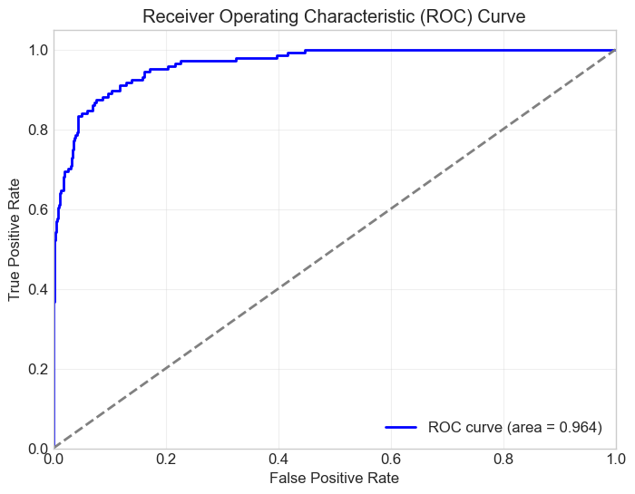

```
Improving Decision Tree...
Best parameters: {'criterion': 'gini', 'max_depth': 5, 'min_samples_leaf': 1, 'min_samples_split': 2}
Accuracy: 0.9847
Precision: 0.8954
Recall: 0.9514
F1-score: 0.9226
ROC-AUC: 0.9951
```

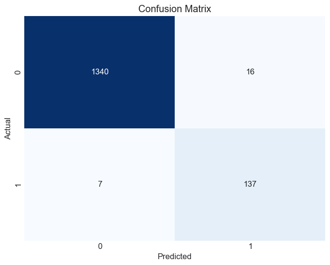

```
Classification Report:
              precision    recall  f1-score   support

           0       0.99      0.99      0.99      1356
           1       0.90      0.95      0.92       144

    accuracy                           0.98      1500
   macro avg       0.95      0.97      0.96      1500
weighted avg       0.99      0.98      0.98      1500
```

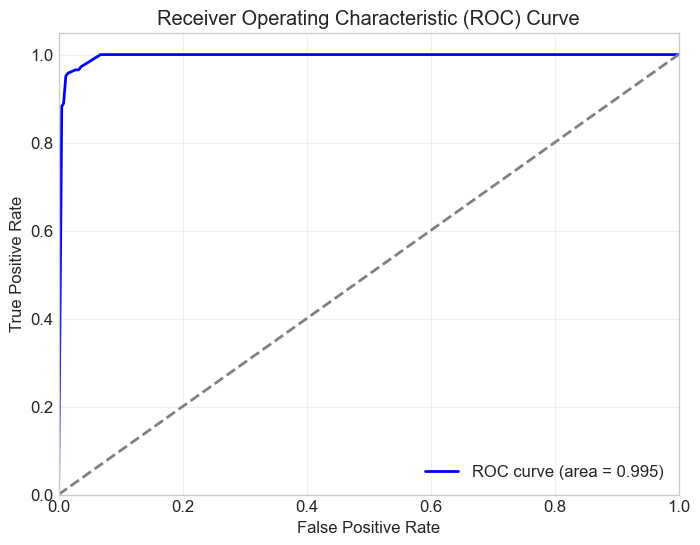

```
Improving Random Forest...
Best parameters: {'max_depth': 10, 'min_samples_leaf': 1, 'min_samples_split': 2, 'n_estimators': 100}
Accuracy: 0.9900
Precision: 0.9778
Recall: 0.9167
F1-score: 0.9462
ROC-AUC: 0.9988
```

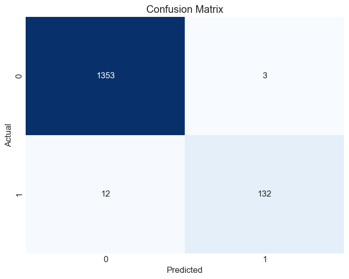

```
Classification Report:
              precision    recall  f1-score   support

           0       0.99      1.00      0.99      1356
           1       0.98      0.92      0.95       144

    accuracy                           0.99      1500
   macro avg       0.98      0.96      0.97      1500
weighted avg       0.99      0.99      0.99      1500
```

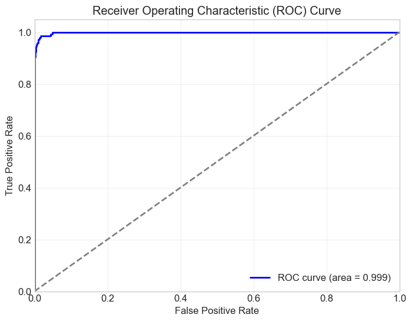

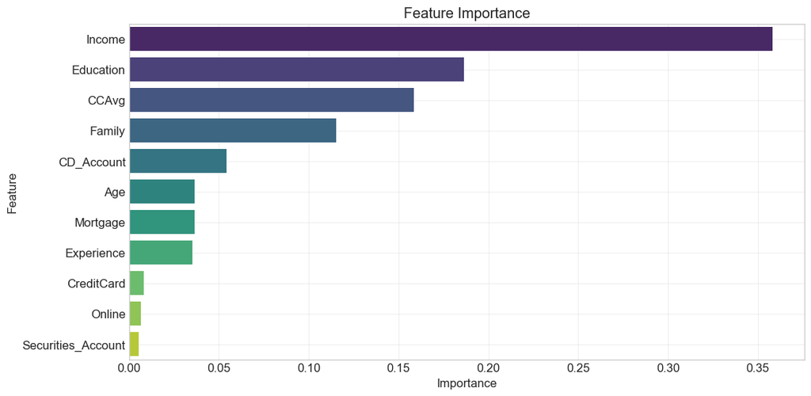

```
Feature Importance:
               Feature  Importance
2               Income    0.358049
5            Education    0.186304
4                CCAvg    0.158513
3               Family    0.115175
8           CD_Account    0.054213
0                  Age    0.036340
6             Mortgage    0.036278
1           Experience    0.035364
10          CreditCard    0.008099
9               Online    0.006459
7   Securities_Account    0.005204
```

```python
# Use GridSearchCV to find the best hyperparameters for each model

# 1. Improved Logistic Regression
print("Improving Logistic Regression...")
lr_param_grid = {
    'C': [0.01, 0.1, 1, 10, 100],
    'penalty': ['l1', 'l2'],
    'solver': ['liblinear', 'saga']
}
lr_grid = GridSearchCV(LogisticRegression(random_state=42, max_iter=1000),
                       lr_param_grid, cv=5, scoring='f1')
lr_grid.fit(X_train, y_train)
print(f"Best parameters: {lr_grid.best_params_}")
lr_improved = lr_grid.best_estimator_
lr_improved_results = evaluate_model(lr_improved, X_train, X_test, y_train, y_test)

# 2. Improved Decision Tree
print("\nImproving Decision Tree...")
dt_param_grid = {
    'max_depth': [3, 5, 7, 10, None],
    'min_samples_split': [2, 5, 10],
    'min_samples_leaf': [1, 2, 4],
    'criterion': ['gini', 'entropy']
}
dt_grid = GridSearchCV(DecisionTreeClassifier(random_state=42),
                       dt_param_grid, cv=5, scoring='f1')
dt_grid.fit(X_train, y_train)
print(f"Best parameters: {dt_grid.best_params_}")
dt_improved = dt_grid.best_estimator_
dt_improved_results = evaluate_model(dt_improved, X_train, X_test, y_train, y_test)



# 3. Improved Random Forest
print("\nImproving Random Forest...")
rf_param_grid = {
    'n_estimators': [50, 100, 200],
    'max_depth': [5, 10, None],
    'min_samples_split': [2, 5, 10],
    'min_samples_leaf': [1, 2, 4]
}
rf_grid = GridSearchCV(RandomForestClassifier(random_state=42),
                       rf_param_grid, cv=5, scoring='f1')
rf_grid.fit(X_train, y_train)
print(f"Best parameters: {rf_grid.best_params_}")
rf_improved = rf_grid.best_estimator_
rf_improved_results = evaluate_model(rf_improved, X_train, X_test, y_train, y_test)


# Feature importance from the best model (Random Forest)
if hasattr(rf_improved, 'feature_importances_'):
    importances = rf_improved.feature_importances_
    feature_importances = pd.DataFrame({
        'Feature': X_train.columns,
        'Importance': importances
    }).sort_values(by='Importance', ascending=False)

    plt.figure(figsize=(12, 6))
    sns.barplot(x='Importance', y='Feature', data=feature_importances, palette='viridis')
    plt.title('Feature Importance')
    plt.xlabel('Importance')
    plt.ylabel('Feature')
    plt.grid(True, alpha=0.3)
    plt.show()

    print("\nFeature Importance:")
    print(feature_importances)
```

## Model Performance Comparison and Final Model Selection

```
Model Comparison:
```

|  | Model | Accuracy | Precision | Recall | F1-score | ROC-AUC |
| --- | --- | --- | --- | --- | --- | --- |
| 0 | Logistic Regression | 0.950000 | 0.810811 | 0.625000 | 0.705882 | 0.964346 |
| 1 | Decision Tree | 0.980667 | 0.891156 | 0.909722 | 0.900344 | 0.948961 |
| 2 | Random Forest | 0.989333 | 0.970588 | 0.916667 | 0.942857 | 0.998423 |
| 3 | Improved Logistic Regression | 0.952000 | 0.815789 | 0.645833 | 0.720930 | 0.964003 |
| 4 | Improved Decision Tree | 0.984667 | 0.895425 | 0.951389 | 0.922559 | 0.995127 |
| 5 | Improved Random Forest | 0.990000 | 0.977778 | 0.916667 | 0.946237 | 0.998766 |

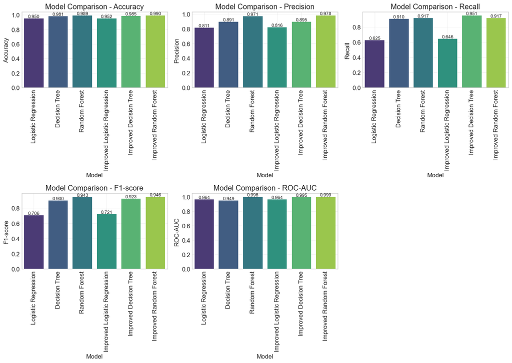

```
Best Model: Improved Random Forest
F1-score: 0.9462
```

```python
models = {
    'Logistic Regression': lr_results,
    'Decision Tree': dt_results,
    'Random Forest': rf_results,
    'Improved Logistic Regression': lr_improved_results,
    'Improved Decision Tree': dt_improved_results,
    'Improved Random Forest': rf_improved_results
}


# Comparison dataframe
comparison_df = pd.DataFrame({
    'Model': list(models.keys()),
    'Accuracy': [models[m]['accuracy'] for m in models],
    'Precision': [models[m]['precision'] for m in models],
    'Recall': [models[m]['recall'] for m in models],
    'F1-score': [models[m]['f1_score'] for m in models],
    'ROC-AUC': [models[m]['roc_auc'] for m in models]
})

print("\nModel Comparison:")
display(comparison_df)

# Visualize comparison
plt.figure(figsize=(14, 10))
metrics = ['Accuracy', 'Precision', 'Recall', 'F1-score', 'ROC-AUC']
for i, metric in enumerate(metrics, 1):
    plt.subplot(2, 3, i)
    ax = sns.barplot(x='Model', y=metric, data=comparison_df, palette='viridis')
    plt.title(f'Model Comparison - {metric}')
    plt.xticks(rotation=90)
    plt.grid(True, alpha=0.3)
    for bar in ax.patches:
        ax.text(bar.get_x() + bar.get_width()/2.,
                bar.get_height() + 0.01,
                f'{bar.get_height():.3f}',
                ha='center', fontsize=9)

plt.tight_layout()
plt.show()

# Identify the best model based on F1-score
best_model_name = comparison_df.loc[comparison_df['F1-score'].idxmax(), 'Model']
best_model = models[best_model_name]['model']
print(f"\nBest Model: {best_model_name}")
print(f"F1-score: {comparison_df.loc[comparison_df['F1-score'].idxmax(), 'F1-score']:.4f}")
```

## Actionable Insights and Business Recommendations

- What recommedations would you suggest to the bank?
1. **Customer Segmentation Focus:**
   - High income customers show a greater propensity to take personal loans. The bank should focus its marketing efforts on customers with higher income brackets.
   - Customers with higher average credit card spending (CCAvg) are also more likely to take personal loans, suggesting they are comfortable with taking credit products.
2. **Targetted Marketting:**
   - Customers with higher education levels (advanced/professional degrees) show greater interest in personal loans. The bank could develop tailored marketing campaigns for different education segments.
3. **Consider Family size:**
   - Customers with larger family sizes show a higher tendency to take personal loans, possibly due to greater financial needs. Marketing campaigns could highlight how personal loans can help manage family expenses.